# METHODS for ‘same data different analysts’ project, ‘Many EcoEvo Analysts’ dataset

Luke J. Eberhart-Phillips and Martin Bulla

2020-08-08 14:35:40

# General background

Upon reading the data description and metadata for ‘Many EcoEvo Analysts’ dataset provided by the [project coordinators of ‘same data different analysts’ project](https://osf.io/34fzc/) we have [**A PRIORI** decided upon the procedures and analyses](https://github.com/MartinBulla/many_analysts/blob/master/Methods/Protocol.Rmd) to answer the key **question**: **“To what extent is the growth of nestling blue tits (Cyanistes caeruleus) influenced by competition with siblings?”**.

We have anticipated, but not expected, that the actual data differ from the [data description](https://github.com/MartinBulla/many_analysts/tree/master/info_from_coordinators). Although the nests with reduced and increased brood size are well matched by hatch date (Figure 1), in 20% they differ by more than one chick in hatched brood size and in 9% of case the differences are extreme (i.e., brood size differences of 3 or more chicks).

#### Figure 1. Frequency distribution of brood size (left) and hatch date differences (right) in paired nests.

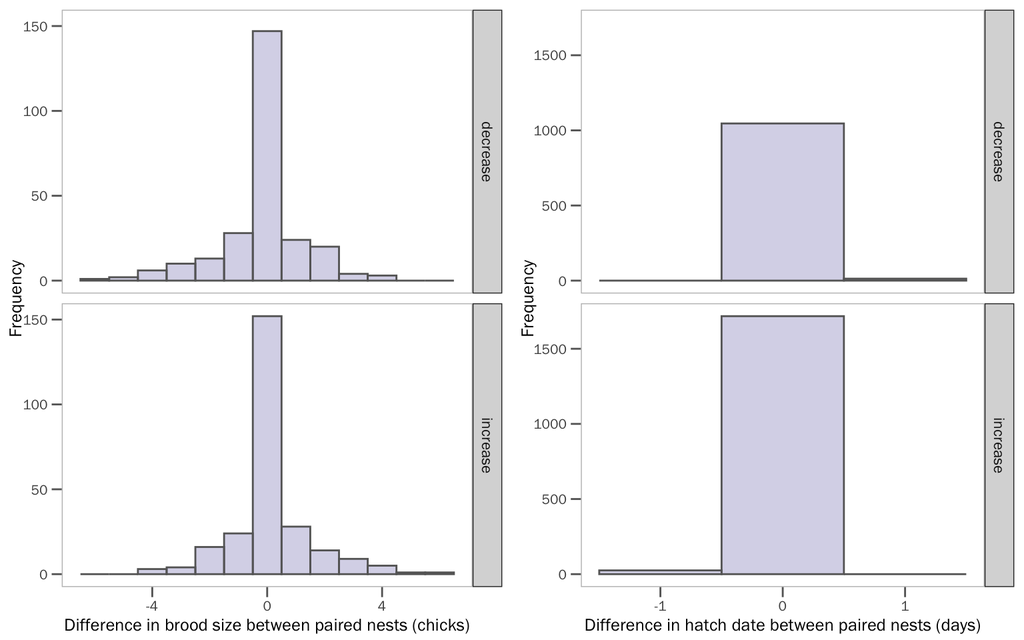

#### Table 1. Frequency distribution of brood size differences in paired nests

| Difference in brood size between paired nests (chicks) | Frequency of cases | Percentage (%) |
| --- | --- | --- |
| 0 | 299 | 55.7 |
| 1 | 104 | 19.4 |
| 2 | 63 | 11.7 |
| 3 or more | 49 | 9.1 |
| NA | 22 | 4.1 |

Importantly, the data description indicated that in broods with 4-5 chicks only one chick was taken or added and in broods with 12-16 chicks four chicks were taken or added. This is not the case. Broods of different than indicated size were used and other chick numbers were added and taken (Figure 2). Also, have not expected that a key variable number of chicks at the start of experiment ‘rear_Cs_at_start_of_rearing’ will be missing 90% of the cases. Thus, we do not use this variable in chick size models (see below)

#### Figure 2. Number of chicks moved in relation to original brood size.

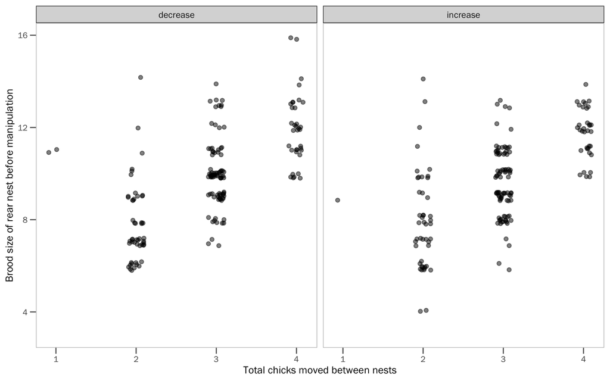

Please see [here](https://raw.githack.com/MartinBulla/many_analysts/data_exploration/R/data_exploration_and_analytical_decisions.html) for our entire data exploration workflow.

# Model specification

We have two main sets of the models, as specified in our [a priori protocol](https://raw.githack.com/MartinBulla/many_analysts/master/MS/Protocol.html) and additional exploratory models as a part of extended material.

## (1) Chick mortality model

We specified the change in chick number in the rearing nests (`change_chick_n`) as a difference between the number of chicks at the start of the experiment (`rear_Cs_at_start_of_rearing`) and number of chicks on day 14 of the experiment (`d14_rear_nest_brood_size`) and fitted this variable as response. The number of chicks to enlarge or reduce the brood (`net_rearing_manipulation`; range -4 to 4, median 0; note that zero indicates the control nests) and brood sex ratio (`brood_sex_ratio`; range 0-1, median 0.5) as explanatory variables. Brood sex ratio was calculated as proportion of males in the nest (1 = all males, 0 = all females), while indicating unknown sex of chicks as 0.5. We specified the observer (`day14_measurer`), the compartment of the study area (`rear_area`), the year (`hatch_year`) and the day on which the rear nest hatched left centered within year, i.e. minimum day within each year subtracted from year hatch day of that given year (`rear_nest_OH_l`) as random intercepts. In total, we had 357 nests forwhich these data were available.

#### Weight model

```r
    lmer(day_14_weight ~
         net_rearing_manipulation + chick_sex_molec +
         brood_sex_ratio +
         (1|day14_measurer) +
         (1|rear_area) +
         (1|rear_nest_OH_l) +
         (1|hatch_year)  +
         (1|rear_nest_breed_ID) +
         (1|hatch_mom_Ring) +
         (1|genetic_dad),
         REML = TRUE
         )
```

#### Body Mass Index model

```r
    lmer(body_mass_index
         net_rearing_manipulation + chick_sex_molec +
         brood_sex_ratio +
         (1|day14_measurer) +
         (1|rear_area) +
         (1|rear_nest_OH_l) +
         (1|hatch_year)  +
         (1|rear_nest_breed_ID) +
         (1|hatch_mom_Ring) +
         (1|genetic_dad),
         REML = TRUE
         )
```

We then specified a model (as indicated in our [a priori protocol](https://github.com/MartinBulla/many_analysts/blob/master/Methods/Protocol.Rmd)] - with sex in interaction with net change in chick numbers `net_rearing_manipulation` to verify whether the effects of the treatment differs between females and males.

#### Tarsus model *with* interaction between sex and number of chicks moved

```r
    lmer(day_14_tarsus_length ~
         net_rearing_manipulation * chick_sex_molec +
         brood_sex_ratio +
         (1|day14_measurer) +
         (1|rear_area) +
         (1|rear_nest_OH_l) +
         (1|hatch_year)  +
         (1|rear_nest_breed_ID) +
         (1|hatch_mom_Ring) +
         (1|genetic_dad),
         REML = TRUE
         )
```

#### Weight model *with* interaction between sex and number of chicks moved

```r
    lmer(day_14_weight ~
         net_rearing_manipulation * chick_sex_molec +
         brood_sex_ratio +
         (1|day14_measurer) +
         (1|rear_area) +
         (1|rear_nest_OH_l) +
         (1|hatch_year)  +
         (1|rear_nest_breed_ID) +
         (1|hatch_mom_Ring) +
         (1|genetic_dad),
         REML = TRUE
         )
```